# STA380 Homework 2 Barton, Jace

Jace Barton

August 19, 2015

First, I load the libraries I will need.

```r
library(RCurl)
```

```r
library(ggplot2)
library(reshape)
library(plyr)
library(tm)
library(caret)
library(kknn)
library(e1071)
library(randomForest)
library(arules)
```

I will run a random forest model in this homework. Thus, I will set the random seed so my results can be reproduced.

```r
set.seed(722)
```

Now I’m ready to begin.

# Graph Creation

## Flights at ABIA

First, I will load in the data for the analysis.

```r
AirportURLString = getURL("https://raw.githubusercontent.com/jacebarton/STA380/master/data/ABIA.csv", ssl.verifypeer=0L, followlocation = 1L)
Airport = read.csv(text=AirportURLString)
summary(Airport)
```

```
##       Year          Month         DayofMonth      DayOfWeek
##  Min.   :2008   Min.   : 1.00   Min.   : 1.00   Min.   :1.000
##  1st Qu.:2008   1st Qu.: 3.00   1st Qu.: 8.00   1st Qu.:2.000
##  Median :2008   Median : 6.00   Median :16.00   Median :4.000
##  Mean   :2008   Mean   : 6.29   Mean   :15.73   Mean   :3.902
##  3rd Qu.:2008   3rd Qu.: 9.00   3rd Qu.:23.00   3rd Qu.:6.000
##  Max.   :2008   Max.   :12.00   Max.   :31.00   Max.   :7.000
##
##     DepTime       CRSDepTime      ArrTime       CRSArrTime
##  Min.   :   1   Min.   :  55   Min.   :   1   Min.   :   5
##  1st Qu.: 917   1st Qu.: 915   1st Qu.:1107   1st Qu.:1115
##  Median :1329   Median :1320   Median :1531   Median :1535
##  Mean   :1329   Mean   :1320   Mean   :1487   Mean   :1505
##  3rd Qu.:1728   3rd Qu.:1720   3rd Qu.:1903   3rd Qu.:1902
##  Max.   :2400   Max.   :2346   Max.   :2400   Max.   :2400
##  NA's   :1413                  NA's   :1567
##  UniqueCarrier     FlightNum       TailNum      ActualElapsedTime
##  WN     :34876   Min.   :   1          : 1104   Min.   : 22.0
##  AA     :19995   1st Qu.: 640   N678CA :  195   1st Qu.: 57.0
##  CO     : 9230   Median :1465   N511SW :  180   Median :125.0
##  YV     : 4994   Mean   :1917   N526SW :  176   Mean   :120.2
##  B6     : 4798   3rd Qu.:2653   N528SW :  172   3rd Qu.:164.0
##  XE     : 4618   Max.   :9741   N520SW :  168   Max.   :506.0
##  (Other):20749                  (Other):97265   NA's   :1601
##  CRSElapsedTime     AirTime          ArrDelay           DepDelay
##  Min.   : 17.0   Min.   :  3.00   Min.   :-129.000   Min.   :-42.000
##  1st Qu.: 58.0   1st Qu.: 38.00   1st Qu.:  -9.000   1st Qu.: -4.000
##  Median :130.0   Median :105.00   Median :  -2.000   Median :  0.000
##  Mean   :122.1   Mean   : 99.81   Mean   :   7.065   Mean   :  9.171
##  3rd Qu.:165.0   3rd Qu.:142.00   3rd Qu.:  10.000   3rd Qu.:  8.000
##  Max.   :320.0   Max.   :402.00   Max.   : 948.000   Max.   :875.000
##  NA's   :11      NA's   :1601     NA's   :1601       NA's   :1413
##      Origin           Dest          Distance        TaxiIn
##  AUS    :49623   AUS    :49637   Min.   :  66   Min.   :  0.000
##  DAL    : 5583   DAL    : 5573   1st Qu.: 190   1st Qu.:  4.000
##  DFW    : 5508   DFW    : 5506   Median : 775   Median :  5.000
##  IAH    : 3704   IAH    : 3691   Mean   : 705   Mean   :  6.413
##  PHX    : 2786   PHX    : 2783   3rd Qu.:1085   3rd Qu.:  7.000
##  DEN    : 2719   DEN    : 2673   Max.   :1770   Max.   :143.000
##  (Other):29337   (Other):29397                  NA's   :1567
```

[output cut: 9 more lines]

```
##  Min.   :  0.00   Min.   :  0.00   Min.   :  0.00   Min.   :  0.00
##  1st Qu.:  0.00   1st Qu.:  0.00   1st Qu.:  0.00   1st Qu.:  0.00
##  Median :  0.00   Median :  0.00   Median :  2.00   Median :  0.00
##  Mean   : 15.39   Mean   :  2.24   Mean   : 12.47   Mean   :  0.07
##  3rd Qu.: 16.00   3rd Qu.:  0.00   3rd Qu.: 16.00   3rd Qu.:  0.00
##  Max.   :875.00   Max.   :412.00   Max.   :367.00   Max.   :199.00
##  NA's   :79513    NA's   :79513    NA's   :79513    NA's   :79513
##  LateAircraftDelay
##  Min.   :  0.00
##  1st Qu.:  0.00
##  Median :  6.00
##  Mean   : 22.97
##  3rd Qu.: 30.00
##  Max.   :458.00
##  NA's   :79513
```

I immediately key in on delays as being the most interesting information in this dataset. For a given aircraft, are delays consistent for flights leaving Austin versus arriving in Austin?

To answer this, I first must split the dataset in two - one half for all of the flights leaving Austin, the other for all the flights arriving in Austin.

```r
DepartureDelay <- data.frame(carrier=Airport$UniqueCarrier, delay=Airport$DepDelay, leaving=Airport$Origin)
head(DepartureDelay)
```

```
##   carrier delay leaving
## 1      9E   345     MEM
## 2      AA    -5     AUS
## 3      YV     0     AUS
## 4      9E    -4     AUS
## 5      AA     1     AUS
## 6      NW    -9     AUS
```

This first step creates a data frame with all rows from the original data sets and columns for the airline, total delay for that flight, and the city from which the flight departed. I now want to filter this dataset to capture only Austin as the city of departure. I will also omit any rows where the departing city is unknown, as this means the flight was cancelled.

```r
DepartureDelay = DepartureDelay[DepartureDelay$leaving == "AUS", ]
DepartureDelay = na.omit(DepartureDelay)
summary(DepartureDelay)
```

```
##     carrier          delay            leaving
##  WN     :17343   Min.   :-36.000   AUS    :48893
##  AA     : 9709   1st Qu.: -5.000   ABQ    :    0
##  CO     : 4554   Median : -1.000   ATL    :    0
##  YV     : 2456   Mean   :  7.425   BHM    :    0
##  B6     : 2367   3rd Qu.:  5.000   BNA    :    0
##  XE     : 2296   Max.   :875.000   BOS    :    0
##  (Other):10168                     (Other):    0
```

I can tell from the summary that this split the data almost exactly in half. I now need to aggregate delay information by carrier.

```r
CarrierDepartureDelays = ddply(DepartureDelay, ~carrier, summarise, mean=mean(delay), sd=sd(delay))
CarrierDepartureDelays
```

```
##    carrier      mean       sd
## 1       9E  3.656501 33.87182
## 2       AA  5.877536 28.25968
## 3       B6 10.451204 44.46459
## 4       CO  7.563900 32.73256
## 5       DL 12.099432 41.78871
## 6       EV 14.000000 40.72907
## 7       F9  1.599624 23.23526
## 8       MQ  7.820884 33.50115
## 9       NW  8.081967 48.06672
## 10      OH  9.926863 32.36067
## 11      OO  7.521761 33.37378
## 12      UA  5.833153 33.78858
## 13      US -0.778542 12.83104
## 14      WN  8.648158 24.97914
## 15      XE  5.597125 31.33525
## 16      YV  6.010586 35.25976
```

This completes my pre-processing for departing flights. I now need to do the same thing for arriving flights before final clean up.

```r
ArrivalDelay <- data.frame(carrier=Airport$UniqueCarrier, delay=Airport$ArrDelay, arriving=Airport$Dest)
head(DepartureDelay)
```

```
##   carrier delay leaving
## 2      AA    -5     AUS
## 3      YV     0     AUS
## 4      9E    -4     AUS
## 5      AA     1     AUS
## 6      NW    -9     AUS
## 7      CO    -9     AUS
```

```r
ArrivalDelay = ArrivalDelay[ArrivalDelay$arriving == "AUS", ]
ArrivalDelay = na.omit(ArrivalDelay)
summary(ArrivalDelay)
```

```
##     carrier          delay            arriving
##  WN     :17324   Min.   :-81.000   AUS    :48863
##  AA     : 9708   1st Qu.: -9.000   ABQ    :    0
##  CO     : 4555   Median : -1.000   ATL    :    0
##  YV     : 2467   Mean   :  8.091   BNA    :    0
##  B6     : 2365   3rd Qu.: 12.000   BOS    :    0
##  XE     : 2288   Max.   :518.000   BWI    :    0
##  (Other):10156                     (Other):    0
```

```r
CarrierArrivalDelays = ddply(ArrivalDelay, ~carrier, summarise, mean=mean(delay), sd=sd(delay))
CarrierArrivalDelays
```

```
##    carrier      mean       sd
## 1       9E  3.518815 31.61852
## 2       AA  9.663473 34.46742
## 3       B6  9.610148 48.45161
## 4       CO  9.113063 35.08589
## 5       DL 12.979206 35.32323
## 6       EV 10.590571 38.63670
## 7       F9  5.172770 23.22650
## 8       MQ  6.428228 27.73061
## 9       NW 11.649123 49.13193
## 10      OH 15.274793 44.11506
## 11      OO  9.953854 36.11016
## 12      UA 12.237838 37.12183
## 13      US -2.640110 22.33975
## 14      WN  5.495324 29.89158
## 15      XE  6.173077 32.31526
## 16      YV 16.282529 47.60905
```

I now want to merge these two separate data frames. I also want to make the data more clear by using the airline name instead of the airline unique code.

```r
CarrierDelays = merge(CarrierArrivalDelays, CarrierDepartureDelays, by="carrier")
CarrierDelays$CarrierNames = c("Pinnacle", "American", "JetBlue", "Continental", "Delta", "AtlanticSE", "Frontier", "Envoy", "Northwest", "Comair", "SkyWest", "United", "US", "Southwest", "ExpressJet", "Mesa")
CarrierDelays
```

```
##    carrier    mean.x     sd.x    mean.y     sd.y CarrierNames
## 1       9E  3.518815 31.61852  3.656501 33.87182     Pinnacle
## 2       AA  9.663473 34.46742  5.877536 28.25968     American
## 3       B6  9.610148 48.45161 10.451204 44.46459      JetBlue
## 4       CO  9.113063 35.08589  7.563900 32.73256  Continental
## 5       DL 12.979206 35.32323 12.099432 41.78871        Delta
## 6       EV 10.590571 38.63670 14.000000 40.72907   AtlanticSE
## 7       F9  5.172770 23.22650  1.599624 23.23526     Frontier
## 8       MQ  6.428228 27.73061  7.820884 33.50115        Envoy
## 9       NW 11.649123 49.13193  8.081967 48.06672    Northwest
## 10      OH 15.274793 44.11506  9.926863 32.36067       Comair
## 11      OO  9.953854 36.11016  7.521761 33.37378      SkyWest
## 12      UA 12.237838 37.12183  5.833153 33.78858       United
## 13      US -2.640110 22.33975 -0.778542 12.83104           US
## 14      WN  5.495324 29.89158  8.648158 24.97914    Southwest
## 15      XE  6.173077 32.31526  5.597125 31.33525   ExpressJet
## 16      YV 16.282529 47.60905  6.010586 35.25976         Mesa
```

Lastly, I will be interested in the total count of flights into and out of Austin for each airline. I will add this as a column. While I’m at it, I’ll change the column names to be more meaningful.

```r
CarrierDelays$Count = summary(Airport$UniqueCarrier)
colnames(CarrierDelays) = c("CarrierCode", "MeanDepartureDelay", "SDDepartureDelay", "MeanArrivalDelay", "SDArrivalDelay", "CarrierNames", "Count")
CarrierDelays
```

```
##    CarrierCode MeanDepartureDelay SDDepartureDelay MeanArrivalDelay
## 1           9E           3.518815         31.61852         3.656501
## 2           AA           9.663473         34.46742         5.877536
## 3           B6           9.610148         48.45161        10.451204
## 4           CO           9.113063         35.08589         7.563900
## 5           DL          12.979206         35.32323        12.099432
## 6           EV          10.590571         38.63670        14.000000
## 7           F9           5.172770         23.22650         1.599624
## 8           MQ           6.428228         27.73061         7.820884
## 9           NW          11.649123         49.13193         8.081967
## 10          OH          15.274793         44.11506         9.926863
## 11          OO           9.953854         36.11016         7.521761
## 12          UA          12.237838         37.12183         5.833153
## 13          US          -2.640110         22.33975        -0.778542
## 14          WN           5.495324         29.89158         8.648158
```

[output cut: 19 more lines]

Now, what’s all this been for? I want to get a picture of which airline is the best choice if I want to minimize my delays. I’d prefer my airline to be below average amongst all airlines in average delay on each leg of my trip - both departing and arriving. This can be seen in the following plot.

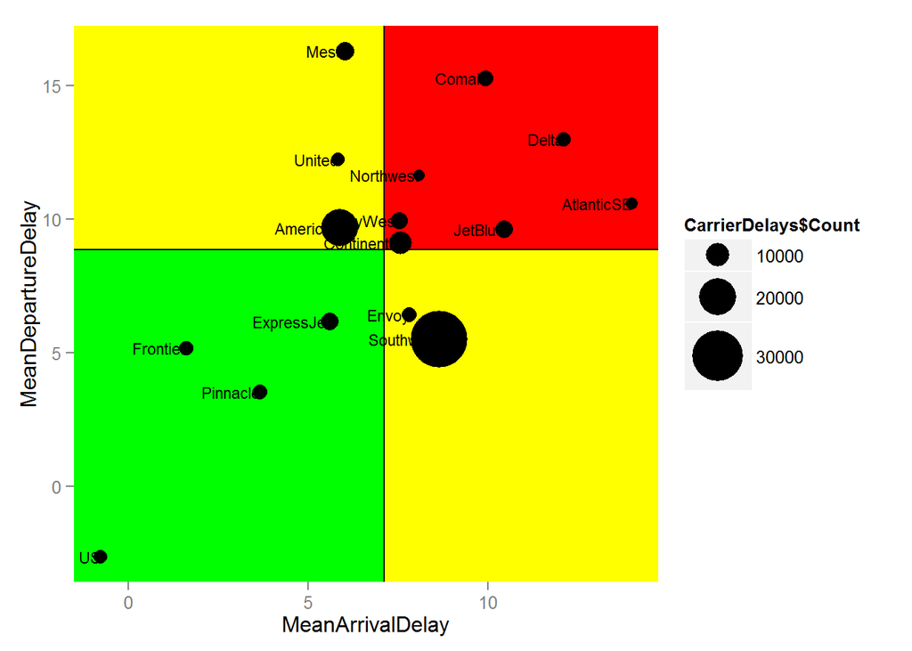

```r
ggplot(CarrierDelays, aes(x=MeanArrivalDelay, y=MeanDepartureDelay, label=CarrierNames)) + annotate("rect", xmin = -Inf, xmax = mean(CarrierDelays$MeanArrivalDelay), ymin = -Inf, ymax = mean(CarrierDelays$MeanDepartureDelay), fill= "green")  +
  annotate("rect", xmin = -Inf, xmax = mean(CarrierDelays$MeanArrivalDelay), ymin = mean(CarrierDelays$MeanDepartureDelay), ymax = Inf , fill= "yellow") +
  annotate("rect", xmin = mean(CarrierDelays$MeanArrivalDelay), xmax = Inf, ymin = -Inf, ymax = mean(CarrierDelays$MeanDepartureDelay), fill= "yellow") +
  annotate("rect", xmin = mean(CarrierDelays$MeanArrivalDelay), xmax = Inf, ymin = mean(CarrierDelays$MeanDepartureDelay), ymax = Inf, fill= "red") +
  geom_point(aes(size=CarrierDelays$Count)) + geom_vline(xintercept=mean(CarrierDelays$MeanArrivalDelay)) + geom_hline(yintercept=mean(CarrierDelays$MeanDepartureDelay)) + scale_size_continuous(range=c(3,15)) + geom_text(size=3, hjust=1)
```

Dots in the green square have smaller delays on average both arriving and departing, whereas dots in the red square have larger delays on average in both directions. The dot size is proportional to the number of flights the airline has into and out of Austin.

# Text Analysis

## Author Attribution

For simplicity, this analysis will ignore words from the test data set which are not in the training data set.

First, I pass in a function I will need to read the text data.

```r
readerPlain = function(fname){
  readPlain(elem=list(content=readLines(fname)),
            id=fname, language='en') }
```

```r
#Get all files
train_author_dirs = Sys.glob('../data/ReutersC50/C50train/*')
train_file_list = NULL
train_labels = NULL
#build a single corpus
for(author in train_author_dirs) {
  author_name = substring(author, first=29)
  files_to_add = Sys.glob(paste0(author, '/*.txt'))
  train_file_list = append(train_file_list, files_to_add)
  train_labels = append(train_labels, rep(author_name, length(files_to_add)))
}

# Need a more clever regex to get better names here
train_all_docs = lapply(train_file_list, readerPlain)
names(train_all_docs) = sub('.txt', '', names(train_all_docs))

train_corpus = Corpus(VectorSource(train_all_docs))
names(train_corpus) = train_file_list

# Clean up tokens in corpus
train_corpus = tm_map(train_corpus, tolower) # make everything lowercase
train_corpus = tm_map(train_corpus, removeNumbers) # remove numbers
train_corpus = tm_map(train_corpus, removePunctuation) # remove punctuation
train_corpus = tm_map(train_corpus, stripWhitespace) ## remove excess white-space
train_corpus = tm_map(train_corpus, removeWords, stopwords("SMART"))

Train_Document_Term_Matrix = DocumentTermMatrix(train_corpus)
Train_Document_Term_Matrix # some basic summary statistics
```

```
## A document-term matrix (2500 documents, 31423 terms)
##
## Non-/sparse entries: 425955/78131545
## Sparsity           : 99%
## Maximal term length: 36
## Weighting          : term frequency (tf)
```

```r
Train_Document_Term_Matrix = removeSparseTerms(Train_Document_Term_Matrix, 0.975)
tm:::inspect(Train_Document_Term_Matrix[1:10,1:5])
```

```
## A document-term matrix (10 documents, 5 terms)
##
## Non-/sparse entries: 3/47
## Sparsity           : 94%
## Maximal term length: 10
## Weighting          : term frequency (tf)
##
##     Terms
## Docs ability abroad access account accounting
##   1        0      0      1       0          0
##   2        0      0      0       0          0
##   3        0      0      2       0          0
##   4        0      0      0       0          0
##   5        0      0      0       0          0
##   6        0      0      0       0          0
##   7        0      0      0       0          0
##   8        0      0      0       0          0
##   9        0      0      0       0          0
##   10       0      0      4       0          0
```

```r
# Now a dense matrix
Train_Matrix = as.matrix(Train_Document_Term_Matrix)
```

I will repeat the above steps to build out the testing data.

```r
test_author_dirs = Sys.glob('../data/ReutersC50/C50test/*')
test_file_list = NULL
test_labels = NULL
#build a single corpus
for(author in test_author_dirs) {
  author_name = substring(author, first=28)
  files_to_add = Sys.glob(paste0(author, '/*.txt'))
  test_file_list = append(test_file_list, files_to_add)
  test_labels = append(test_labels, rep(author_name, length(files_to_add)))
}

# Need a more clever regex to get better names here
test_all_docs = lapply(test_file_list, readerPlain)
names(test_all_docs) = sub('.txt', '', names(test_all_docs))

test_corpus = Corpus(VectorSource(test_all_docs))
names(test_corpus) = test_file_list

# Clean up tokens in corpus
test_corpus = tm_map(test_corpus, tolower) # make everything lowercase
test_corpus = tm_map(test_corpus, removeNumbers) # remove numbers
test_corpus = tm_map(test_corpus, removePunctuation) # remove punctuation
test_corpus = tm_map(test_corpus, stripWhitespace) ## remove excess white-space
test_corpus = tm_map(test_corpus, removeWords, stopwords("SMART"))

Test_Document_Term_Matrix = DocumentTermMatrix(test_corpus, control = list(dictionary=Terms(Train_Document_Term_Matrix)) )
Test_Document_Term_Matrix # some basic summary statistics
```

```
## A document-term matrix (2500 documents, 1389 terms)
##
## Non-/sparse entries: 246565/3225935
## Sparsity           : 93%
## Maximal term length: 18
## Weighting          : term frequency (tf)
```

```r
tm:::inspect(Test_Document_Term_Matrix[1:10,1:5])
```

```
## A document-term matrix (10 documents, 5 terms)
##
## Non-/sparse entries: 9/41
## Sparsity           : 82%
## Maximal term length: 10
## Weighting          : term frequency (tf)
##
##     Terms
## Docs ability abroad access account accounting
##   1        0      0      0       1          3
##   2        0      0      0       0          0
##   3        0      0      3       0          0
##   4        1      1      0       0          0
##   5        0      0      0       0          0
##   6        0      0      0       0          0
##   7        0      0      0       0          0
##   8        1      0      4       0          0
##   9        1      0      4       0          0
##   10       0      0      0       0          0
```

```r
# Now a dense matrix
Test_Matrix = as.matrix(Test_Document_Term_Matrix)
```

Now, I will build a Naive Bayes model to attempt to classify which test articles belong to which authors.

```r
NaiveBayesModel = naiveBayes(Train_Matrix, as.factor(train_labels), laplace=1)

NaiveBayesPredict = predict(object=NaiveBayesModel,newdata = Test_Matrix)
```

Now that the model is built, I can begin to look at results in different ways.

```r
NaiveBayesResults = as.data.frame(table(NaiveBayesPredict,test_labels))
NaiveBayesResultsTable = table(NaiveBayesPredict, test_labels)
total_correct_vector = rep(0, 50)
predicted_per_author = rep(0,50)
for (i in 1:length(NaiveBayesResultsTable[1,])){
  total_correct_vector[i] = NaiveBayesResultsTable[i, i]
  predicted_per_author[i] = sum(NaiveBayesResultsTable[i,])
}

CorrectByAuthor = data.frame(row.names(NaiveBayesResultsTable), total_correct_vector)
CorrectByAuthor
```

```
##    row.names.NaiveBayesResultsTable. total_correct_vector
## 1                      AaronPressman                   29
## 2                         AlanCrosby                   43
## 3                     AlexanderSmith                    0
## 4                    BenjaminKangLim                   16
## 5                      BernardHickey                    8
## 6                        BradDorfman                    0
## 7                   DarrenSchuettler                    0
## 8                        DavidLawder                   21
## 9                      EdnaFernandes                    0
## 10                       EricAuchard                    1
## 11                    FumikoFujisaki                    7
## 12                    GrahamEarnshaw                    1
## 13                  HeatherScoffield                    2
## 14                     JaneMacartney                    0
```

[output cut: 36 more lines]

```r
PredictedForAuthor = data.frame(row.names(NaiveBayesResultsTable), predicted_per_author)
SortedPredictedForAuthor = PredictedForAuthor[order(-PredictedForAuthor$predicted_per_author),]
SortedPredictedForAuthor
```

```
##    row.names.NaiveBayesResultsTable. predicted_per_author
## 2                         AlanCrosby                  642
## 27                         LydiaZajc                  593
## 8                        DavidLawder                  354
## 26                 KouroshKarimkhany                  243
## 16                      JimGilchrist                  139
## 41                      RogerFillion                   80
## 4                    BenjaminKangLim                   75
## 38                     PeterHumphrey                   74
## 1                      AaronPressman                   59
## 48                        TimFarrand                   50
## 28                    LynneO'Donnell                   29
## 15                        JanLopatka                   28
## 20                    JoWinterbottom                   24
## 40                        RobinSidel                   21
```

[output cut: 36 more lines]

```r
OverallClassificationRate = sum(total_correct_vector)/2500
OverallClassificationRate
```

```
## [1] 0.1776
```

```r
PrecisionRateByAuthor = data.frame(row.names(NaiveBayesResultsTable), total_correct_vector/predicted_per_author)
PrecisionRateByAuthor
```

```
##    row.names.NaiveBayesResultsTable.
## 1                      AaronPressman
## 2                         AlanCrosby
## 3                     AlexanderSmith
## 4                    BenjaminKangLim
## 5                      BernardHickey
## 6                        BradDorfman
## 7                   DarrenSchuettler
## 8                        DavidLawder
## 9                      EdnaFernandes
## 10                       EricAuchard
## 11                    FumikoFujisaki
## 12                    GrahamEarnshaw
## 13                  HeatherScoffield
## 14                     JaneMacartney
```

[output cut: 87 more lines]

I will try a random forest model to see if I get better results.

```r
TrainDataFrame = as.data.frame(Train_Matrix)
TestDataFrame = as.data.frame(Test_Matrix)

set.seed(722)
AuthorRandomForest = randomForest(x=TrainDataFrame, y=as.factor(train_labels), ntree=50, mtry=30)

PredictedAuthor = predict(AuthorRandomForest, newdata = TestDataFrame)
```

```r
RandomForestResults = as.data.frame(table(PredictedAuthor,test_labels))
RandomForestResultsTable = table(PredictedAuthor, test_labels)
RF_total_correct_vector = rep(0, 50)
RF_predicted_per_author = rep(0,50)
for (i in 1:length(RandomForestResultsTable[1,])){
  RF_total_correct_vector[i] = RandomForestResultsTable[i, i]
  RF_predicted_per_author[i] = sum(RandomForestResultsTable[i,])
}

RFCorrectByAuthor = data.frame(row.names(RandomForestResultsTable),RF_total_correct_vector)
RFCorrectByAuthor
```

```
##    row.names.RandomForestResultsTable. RF_total_correct_vector
## 1                        AaronPressman                      42
## 2                           AlanCrosby                      30
## 3                       AlexanderSmith                      19
## 4                      BenjaminKangLim                      16
## 5                        BernardHickey                      31
## 6                          BradDorfman                      29
## 7                     DarrenSchuettler                      14
## 8                          DavidLawder                       9
## 9                        EdnaFernandes                      19
## 10                         EricAuchard                      19
## 11                      FumikoFujisaki                      50
## 12                      GrahamEarnshaw                      43
## 13                    HeatherScoffield                      19
## 14                       JaneMacartney                       8
```

[output cut: 36 more lines]

```r
RFPredictedForAuthor = data.frame(row.names(RandomForestResultsTable), RF_predicted_per_author)
RFSortedPredictedForAuthor = RFPredictedForAuthor[order(-RFPredictedForAuthor$RF_predicted_per_author),]
RFSortedPredictedForAuthor
```

```
##    row.names.RandomForestResultsTable. RF_predicted_per_author
## 46                            TanEeLyn                      82
## 30                     MarcelMichelson                      79
## 19                        JonathanBirt                      74
## 21                         KarlPenhaul                      70
## 49                          ToddNissen                      69
## 26                   KouroshKarimkhany                      68
## 4                      BenjaminKangLim                      65
## 15                          JanLopatka                      65
## 12                      GrahamEarnshaw                      63
## 16                        JimGilchrist                      63
## 38                       PeterHumphrey                      61
## 31                        MarkBendeich                      60
## 1                        AaronPressman                      59
## 13                    HeatherScoffield                      59
```

[output cut: 36 more lines]

```r
RFOverallClassificationRate = sum(RF_total_correct_vector)/2500
RFOverallClassificationRate
```

```
## [1] 0.5764
```

```r
RFPrecisionRateByAuthor = data.frame(row.names(RandomForestResultsTable), RF_total_correct_vector/RF_predicted_per_author)
RFPrecisionRateByAuthor
```

```
##    row.names.RandomForestResultsTable.
## 1                        AaronPressman
## 2                           AlanCrosby
## 3                       AlexanderSmith
## 4                      BenjaminKangLim
## 5                        BernardHickey
## 6                          BradDorfman
## 7                     DarrenSchuettler
## 8                          DavidLawder
## 9                        EdnaFernandes
## 10                         EricAuchard
## 11                      FumikoFujisaki
## 12                      GrahamEarnshaw
## 13                    HeatherScoffield
## 14                       JaneMacartney
```

[output cut: 87 more lines]

Another nice thing about the Random Forest model is I can see which of the tokens were most important in fitting the model.

```r
RFImportance = as.data.frame(importance(AuthorRandomForest))
RFImportanceDataFrame = data.frame(row.names(RFImportance), RFImportance)
SortRFImportance = RFImportanceDataFrame[order(-RFImportanceDataFrame$MeanDecreaseGini),]
SortRFImportance[1:10,]
```

```
##            row.names.RFImportance. MeanDecreaseGini
## czech                        czech         18.81620
## toronto                    toronto         13.90261
## kong                          kong         13.04951
## hong                          hong         12.91905
## cargo                        cargo         12.87677
## french                      french         11.79951
## chinas                      chinas         11.51090
## australian              australian         11.28318
## china                        china         10.92082
## chinese                    chinese         10.84070
```

Interestingly, many international words appear on the list. This leads me to believe that the authors we were most succesfully able to classify write mostly about international items for the paper.

# Association Rules

## Practice with Association Rule Mining

First, I read in the data directly as transaction data and view a summary.

```r
Groceries = read.transactions("../data/groceries.txt", format = "basket", sep=",")
summary(Groceries)
```

```
## transactions as itemMatrix in sparse format with
##  9835 rows (elements/itemsets/transactions) and
##  169 columns (items) and a density of 0.02609146
##
## most frequent items:
##       whole milk other vegetables       rolls/buns             soda
##             2513             1903             1809             1715
##           yogurt          (Other)
##             1372            34055
##
## element (itemset/transaction) length distribution:
## sizes
##    1    2    3    4    5    6    7    8    9   10   11   12   13   14   15
## 2159 1643 1299 1005  855  645  545  438  350  246  182  117   78   77   55
##   16   17   18   19   20   21   22   23   24   26   27   28   29   32
##   46   29   14   14    9   11    4    6    1    1    1    1    3    1
##
##    Min. 1st Qu.  Median    Mean 3rd Qu.    Max.
##   1.000   2.000   3.000   4.409   6.000  32.000
##
## includes extended item information - examples:
##             labels
## 1 abrasive cleaner
## 2 artif. sweetener
## 3   baby cosmetics
```

Whole milk is the most popular item, followed by a generic vegetable category and a generic bread category.

Next, I will create association rules for these transactions using arbitrary cutoffs for support, confidence, and number of items allowed in a rule. I will explore the cutoffs in more detail next.

```r
GroceriesRules <- apriori(Groceries, parameter=list(support=.005, confidence=.5, maxlen=4))
```

```
##
## Parameter specification:
##  confidence minval smax arem  aval originalSupport support minlen maxlen
##         0.5    0.1    1 none FALSE            TRUE   0.005      1      4
##  target   ext
##   rules FALSE
##
## Algorithmic control:
##  filter tree heap memopt load sort verbose
##     0.1 TRUE TRUE  FALSE TRUE    2    TRUE
##
## apriori - find association rules with the apriori algorithm
## version 4.21 (2004.05.09)        (c) 1996-2004   Christian Borgelt
## set item appearances ...[0 item(s)] done [0.00s].
## set transactions ...[169 item(s), 9835 transaction(s)] done [0.00s].
## sorting and recoding items ... [120 item(s)] done [0.00s].
## creating transaction tree ... done [0.00s].
## checking subsets of size 1 2 3 4 done [0.00s].
## writing ... [120 rule(s)] done [0.00s].
## creating S4 object  ... done [0.00s].
```

```r
arules:::inspect(GroceriesRules)
```

```
##     lhs                           rhs                    support confidence     lift
## 1   {baking powder}            => {whole milk}       0.009252669  0.5229885 2.046793
## 2   {oil,
##      other vegetables}         => {whole milk}       0.005083884  0.5102041 1.996760
## 3   {onions,
##      root vegetables}          => {other vegetables} 0.005693950  0.6021505 3.112008
## 4   {onions,
##      whole milk}               => {other vegetables} 0.006609049  0.5462185 2.822942
## 5   {hygiene articles,
##      other vegetables}         => {whole milk}       0.005185562  0.5425532 2.123363
## 6   {other vegetables,
##      sugar}                    => {whole milk}       0.006304016  0.5849057 2.289115
## 7   {long life bakery product,
##      other vegetables}         => {whole milk}       0.005693950  0.5333333 2.087279
## 8   {cream cheese ,
##      yogurt}                   => {whole milk}       0.006609049  0.5327869 2.085141
## 9   {chicken,
##      root vegetables}          => {other vegetables} 0.005693950  0.5233645 2.704829
## 10  {chicken,
##      root vegetables}          => {whole milk}       0.005998983  0.5514019 2.157993
## 11  {chicken,
##      rolls/buns}               => {whole milk}       0.005287239  0.5473684 2.142208
## 12  {coffee,
##      yogurt}                   => {whole milk}       0.005083884  0.5208333 2.038359
## 13  {frozen vegetables,
##      root vegetables}          => {other vegetables} 0.006100661  0.5263158 2.720082
## 14  {frozen vegetables,
##      root vegetables}          => {whole milk}       0.006202339  0.5350877 2.094146
## 15  {frozen vegetables,
##      rolls/buns}               => {whole milk}       0.005083884  0.5000000 1.956825
## 16  {frozen vegetables,
##      other vegetables}         => {whole milk}       0.009659380  0.5428571 2.124552
## 17  {beef,
##      yogurt}                   => {whole milk}       0.006100661  0.5217391 2.041904
## 18  {beef,
##      rolls/buns}               => {whole milk}       0.006812405  0.5000000 1.956825
## 19  {curd,
##      whipped/sour cream}       => {whole milk}       0.005897306  0.5631068 2.203802
## 20  {curd,
##      tropical fruit}           => {yogurt}           0.005287239  0.5148515 3.690645
```

[output cut: 206 more lines]

```
## 116 {tropical fruit,
##      whole milk,
##      yogurt}                   => {other vegetables} 0.007625826  0.5033557 2.601421
## 117 {other vegetables,
##      root vegetables,
##      yogurt}                   => {whole milk}       0.007829181  0.6062992 2.372842
## 118 {root vegetables,
##      whole milk,
##      yogurt}                   => {other vegetables} 0.007829181  0.5384615 2.782853
## 119 {other vegetables,
##      rolls/buns,
##      root vegetables}          => {whole milk}       0.006202339  0.5083333 1.989438
## 120 {other vegetables,
##      rolls/buns,
##      yogurt}                   => {whole milk}       0.005998983  0.5221239 2.043410
```

These cutoffs yield 120 rules. While this is a lot to parse, I notice that a lot of the rules are used to predict when someone will buy whole milk. Since whole milk is the most common item, I want to look at lift in an attempt to “normalize” against how frequent an item is.

```r
arules:::inspect(subset(GroceriesRules, subset=lift > 3))
```

```
##   lhs                     rhs                    support confidence     lift
## 1 {onions,
##    root vegetables}    => {other vegetables} 0.005693950  0.6021505 3.112008
## 2 {curd,
##    tropical fruit}     => {yogurt}           0.005287239  0.5148515 3.690645
## 3 {pip fruit,
##    whipped/sour cream} => {other vegetables} 0.005592272  0.6043956 3.123610
## 4 {citrus fruit,
##    root vegetables}    => {other vegetables} 0.010371124  0.5862069 3.029608
## 5 {root vegetables,
##    tropical fruit}     => {other vegetables} 0.012302999  0.5845411 3.020999
## 6 {pip fruit,
##    root vegetables,
##    whole milk}         => {other vegetables} 0.005490595  0.6136364 3.171368
## 7 {citrus fruit,
##    root vegetables,
##    whole milk}         => {other vegetables} 0.005795628  0.6333333 3.273165
## 8 {root vegetables,
##    tropical fruit,
##    whole milk}         => {other vegetables} 0.007015760  0.5847458 3.022057
```

Let’s now look at rules which occur in more than 1.5% of all transactions.

```r
arules:::inspect(subset(GroceriesRules, subset=support > 0.015))
```

```
##   lhs                   rhs             support confidence     lift
## 1 {tropical fruit,
##    yogurt}           => {whole milk} 0.01514997  0.5173611 2.024770
## 2 {other vegetables,
##    yogurt}           => {whole milk} 0.02226741  0.5128806 2.007235
```

There are only two rules which occur more than 1.5% of the time, and both are used to predict whole milk. From this, we can see that if a customer buys yogurt and produce, they are also very likely to buy whole milk.

Finally, I want to look at the cases where the predicted item occurs most frequently with the predictor items.

```r
arules:::inspect(subset(GroceriesRules, subset=support > .003 & confidence > 0.65))
```

```
##   lhs                     rhs              support confidence     lift
## 1 {butter,
##    whipped/sour cream} => {whole milk} 0.006710727      0.660 2.583008
## 2 {other vegetables,
##    pip fruit,
##    root vegetables}    => {whole milk} 0.005490595      0.675 2.641713
## 3 {root vegetables,
##    tropical fruit,
##    yogurt}             => {whole milk} 0.005693950      0.700 2.739554
```

All of the predicted items in this case involve whole milk. Again, produce and other dairy products show up. These rules all have high lift as well.